# Lecture 08 Supplemental Notebook

# Scale

```python
ppdf = pd.DataFrame(dict(Cancer=[2007371, 935573], Abortion=[289750, 327000]),
                    index=pd.Series([2006, 2013],
                    name="Year"))
ppdf
```

| Year | Cancer | Abortion |
| --- | --- | --- |
| 2006 | 2007371 | 289750 |
| 2013 | 935573 | 327000 |

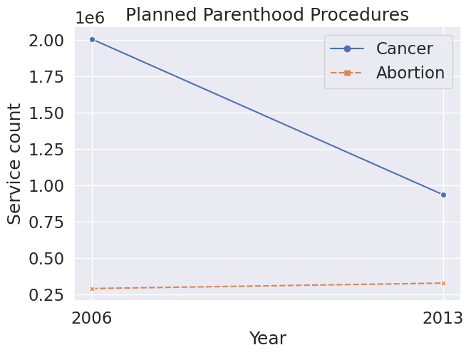

```python
ax = sns.lineplot(data=ppdf, markers=True)
ax.set_title("Planned Parenthood Procedures")
ax.set_xticks([2006, 2013])
ax.set_ylabel("Service count");
```

Let's now compute the relative change between the two years...

```python
rel_change = 100*(ppdf.loc[2013] - ppdf.loc[2006])/ppdf.loc[2006]
rel_change.name = "Percent Change"
rel_change
```

```
Cancer     -53.39312
Abortion    12.85591
Name: Percent Change, dtype: float64
```

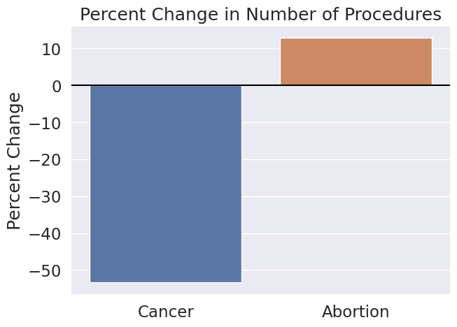

```python
ax = sns.barplot(x=rel_change.index, y=rel_change)
ax.axhline(0, color='black')
ax.set_title("Percent Change in Number of Procedures");
```

## Current Population Survey

```python
cps = pd.read_csv("data/edInc2.csv")
cps
```

|  | educ | gender | income |
| --- | --- | --- | --- |
| 0 | 1 | Men | 517 |
| 1 | 1 | Women | 409 |
| 2 | 2 | Men | 751 |
| 3 | 2 | Women | 578 |
| 4 | 3 | Men | 872 |
| 5 | 3 | Women | 661 |
| 6 | 4 | Men | 1249 |
| 7 | 4 | Women | 965 |
| 8 | 5 | Men | 1385 |
| 9 | 5 | Women | 1049 |

```python
cps = cps.replace({'educ':{1:"<HS", 2:"HS", 3:"<BA", 4:"BA", 5:">BA"}})
cps.columns = ['Education', 'Gender', 'Income']
cps
```

|  | Education | Gender | Income |
| --- | --- | --- | --- |
| 0 | <HS | Men | 517 |
| 1 | <HS | Women | 409 |
| 2 | HS | Men | 751 |
| 3 | HS | Women | 578 |
| 4 | <BA | Men | 872 |
| 5 | <BA | Women | 661 |
| 6 | BA | Men | 1249 |
| 7 | BA | Women | 965 |
| 8 | >BA | Men | 1385 |
| 9 | >BA | Women | 1049 |

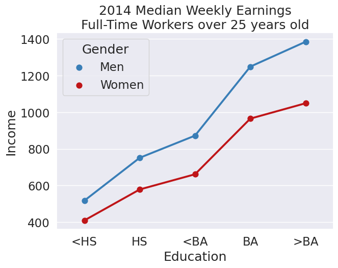

```python
# Let's pick our colors specifically using color_palette()
blue_red = ["#397eb7", "#bf1518"]
with sns.color_palette(sns.color_palette(blue_red)):
    ax = sns.pointplot(data=cps, x = "Education", y = "Income", hue = "Gender")

ax.set_title("2014 Median Weekly Earnings\nFull-Time Workers over 25 years old");
```

Now, let's compute the income gap as a relative quantity between men and women. Recall that the structure of the dataframe is as follows:

```python
cps.head()
```

|  | Education | Gender | Income |
| --- | --- | --- | --- |
| 0 | <HS | Men | 517 |
| 1 | <HS | Women | 409 |
| 2 | HS | Men | 751 |
| 3 | HS | Women | 578 |
| 4 | <BA | Men | 872 |

This calls for using `groupby` by Gender, so that we can separate the data for both genders, and then compute the ratio:

```python
cg = cps.set_index("Education").groupby("Gender")
men = cg.get_group("Men").drop("Gender", axis="columns")
women = cg.get_group("Women").drop("Gender", axis="columns")
display(men, women)
```

| Education | Income |
| --- | --- |
| <HS | 517 |
| HS | 751 |
| <BA | 872 |
| BA | 1249 |
| >BA | 1385 |

| Education | Income |
| --- | --- |
| <HS | 409 |
| HS | 578 |
| <BA | 661 |
| BA | 965 |
| >BA | 1049 |

```python
mfratio = men/women
mfratio.columns = ["Income Ratio (M/F)"]
mfratio
```

| Education | Income Ratio (M/F) |
| --- | --- |
| <HS | 1.264059 |
| HS | 1.299308 |
| <BA | 1.319213 |
| BA | 1.294301 |
| >BA | 1.320305 |

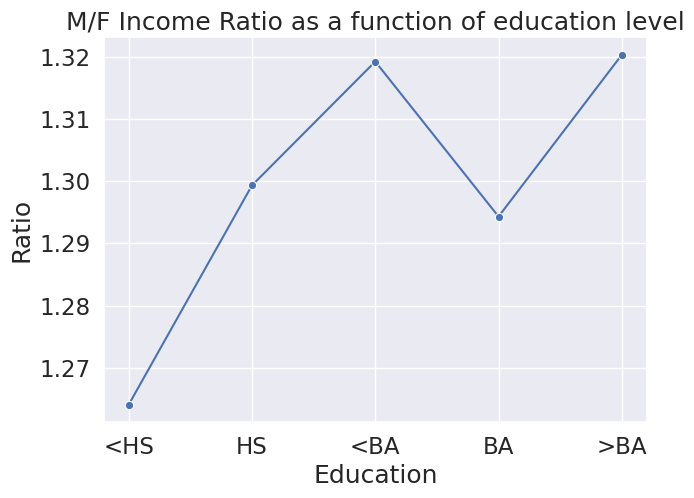

```python
ax = sns.lineplot(data=mfratio, markers=True, legend=False);
ax.set_ylabel("Ratio")
ax.set_title("M/F Income Ratio as a function of education level");
```

Let's now compute the alternate ratio, F/M instead:

```python
fmratio = women/men
fmratio.columns = ["Income Ratio (F/M)"]
fmratio
```

| Education | Income Ratio (F/M) |
| --- | --- |
| <HS | 0.791103 |
| HS | 0.769640 |
| <BA | 0.758028 |
| BA | 0.772618 |
| >BA | 0.757401 |

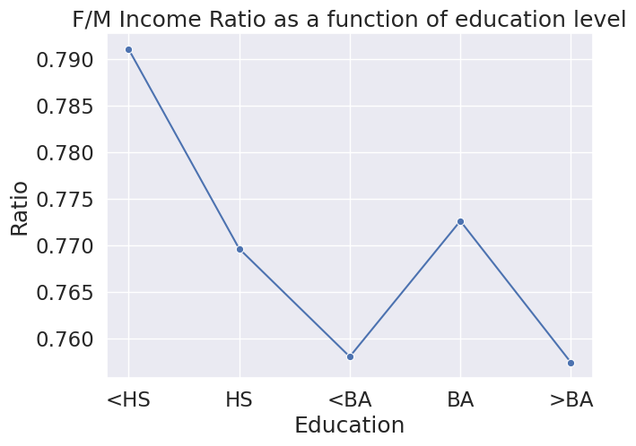

```python
ax = sns.lineplot(data=fmratio, markers=True, legend=False);
ax.set_ylabel("Ratio")
ax.set_title("F/M Income Ratio as a function of education level");
```

## CO2 Emissions

```python
co2 = pd.read_csv("data/CAITcountryCO2.csv", skiprows = 2,
                  names = ["Country", "Year", "CO2"], encoding = "ISO-8859-1")
co2.tail()
```

|  | Country | Year | CO2 |
| --- | --- | --- | --- |
| 30639 | Vietnam | 2012 | 173.0497 |
| 30640 | World | 2012 | 33843.0497 |
| 30641 | Yemen | 2012 | 20.5386 |
| 30642 | Zambia | 2012 | 2.7600 |
| 30643 | Zimbabwe | 2012 | 9.9800 |

```python
last_year = co2.Year.iloc[-1]
last_year
```

```
2012
```

```python
q = f"Country != 'World' and Country != 'European Union (15)' and Year == {last_year}"
top14_lasty = co2.query(q).sort_values('CO2', ascending=False).iloc[:14]
top14_lasty
```

|  | Country | Year | CO2 |
| --- | --- | --- | --- |
| 30490 | China | 2012 | 9312.5329 |
| 30634 | United States | 2012 | 5122.9094 |
| 30514 | European Union (28) | 2012 | 3610.5137 |
| 30533 | India | 2012 | 2075.1808 |
| 30596 | Russian Federation | 2012 | 1721.5376 |
| 30541 | Japan | 2012 | 1249.2135 |
| 30521 | Germany | 2012 | 773.9585 |
| 30547 | Korea, Rep. (South) | 2012 | 617.2418 |
| 30535 | Iran | 2012 | 593.8195 |
| 30485 | Canada | 2012 | 543.0242 |
| 30603 | Saudi Arabia | 2012 | 480.2278 |
| 30478 | Brazil | 2012 | 477.7701 |
| 30633 | United Kingdom | 2012 | 463.4556 |
| 30567 | Mexico | 2012 | 460.4782 |

```python
top14 = co2[co2.Country.isin(top14_lasty.Country) & (co2.Year >= 1950)]
print(len(top14.Country.unique()))
top14.head()
```

```
14
```

|  | Country | Year | CO2 |
| --- | --- | --- | --- |
| 18822 | Brazil | 1950 | 19.6574 |
| 18829 | Canada | 1950 | 154.1408 |
| 18834 | China | 1950 | 78.6478 |
| 18858 | European Union (28) | 1950 | 1773.6864 |
| 18865 | Germany | 1950 | 510.7323 |

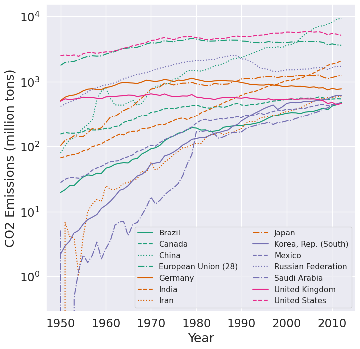

```python
from cycler import cycler

linestyles = ['-', '--', ':', '-.' ]
colors = plt.cm.Dark2.colors
lines_c = cycler('linestyle', linestyles)
color_c = cycler('color', colors)

fig, ax = plt.subplots(figsize=(8, 8))
ax.set_prop_cycle(color_c * lines_c)

x, y ='Year', 'CO2'
for name, df in top14.groupby('Country'):
    ax.semilogy(df[x], df[y], label=name)

ax.set_xlabel(x)
ax.set_ylabel(f"{y} Emissions (million tons)")
ax.legend(ncol=2, frameon=True, fontsize=11);
```